# Where is the Money for Feminist Organizing? Survey for feminist, women’s rights and gender justice movements, groups and organizations

2024-08-15

**-.-.-.-.-.-.-.-.-.-.-.-.-.-.-.-.-.-.-.-.-.-.-.-.-.-.-.-.-.-**

**Section 2.1: External founding**

**Organizations based on external funding received**

Q13. Between 2021 and 2023, did your group, organization and/or movement receive any external funding?

| External funding | n | Percentage |
| --- | --- | --- |
| no | 280 | 28.3 |
| yes | 711 | 71.7 |

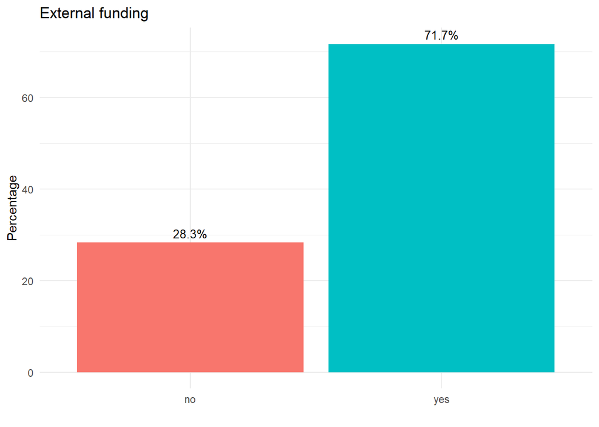

It is noted that 71.7% of organizations participating on the survey have received external funding.

| Registration | no | yes |
| --- | --- | --- |
| No | 48.37 | 51.63 |
| Yes | 23.75 | 76.25 |

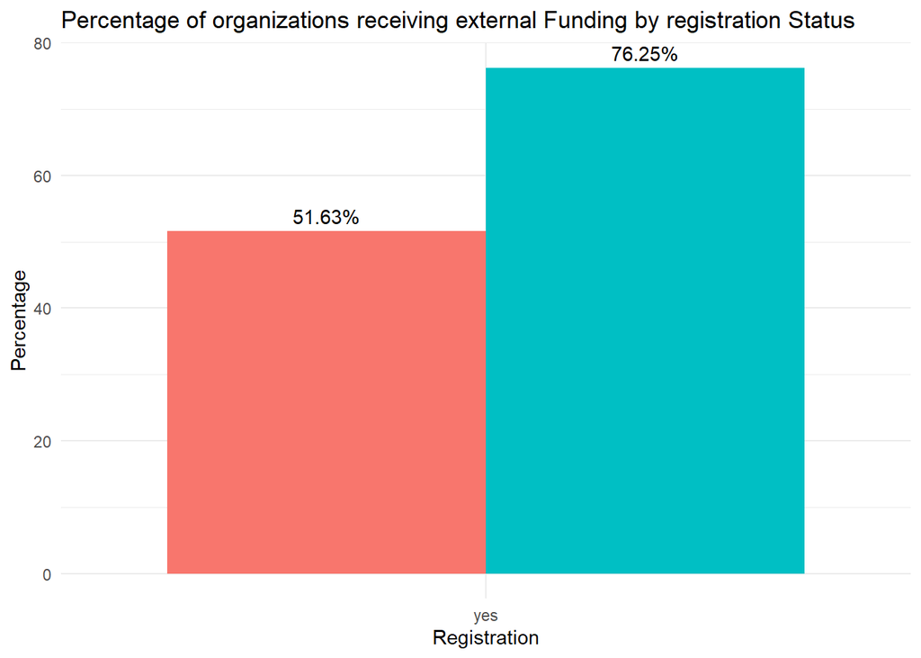

The Percentage of organizations receiving external funding increases to 73.6% among those that promote the rights of women, girls, or trans and gender-diverse individuals with intersecting identities, where this is the ‘primary focus of all our work.’ The Percentage rises to 76.2% among registered organizations, but drops to 51.6% among those that are not registered.

Regarding organizational scope, those with a regional focus receive external funding more frequently. In contrast, less than 66.2% of organizations with a local focus report receiving external funding

| Scope | no | yes |
| --- | --- | --- |
| Diaspora | 18.18 | 81.82 |
| Global | 28.81 | 71.19 |
| Local | 33.75 | 66.25 |
| National | 27.63 | 72.37 |
| Regional | 14.43 | 85.57 |
| Transnational | 26.32 | 73.68 |

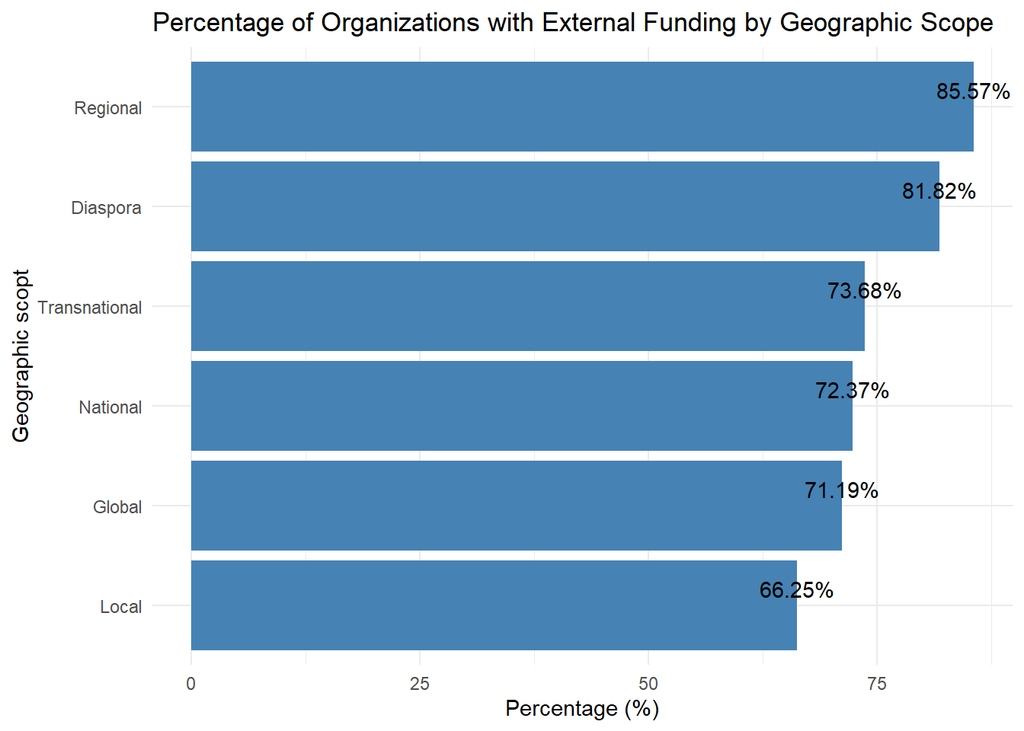

Formation period

no

yes

5. Before 2000

11.35

88.65

4. From 2000 to 2009

16.50

83.50

3. From 2010 to 2014

23.84

76.16

2. From 2015 to 2020

32.21

67.79

1. 2021-2023

55.92

44.08

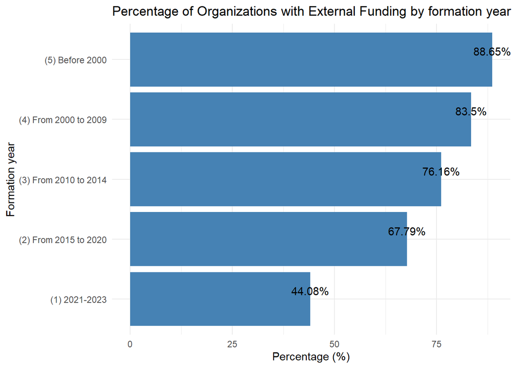

Budget 2023

n

Percentage

8. > 250001

138

95.2

4. 10001-30000

131

85.1

6. 50001 - 100000

102

82.9

7. 100001 - 250000

99

89.2

3. 5001-10000

85

74.6

5. 30001 -50000

75

87.2

2. <5000

64

43.5

1. Zero budget

17

15.3

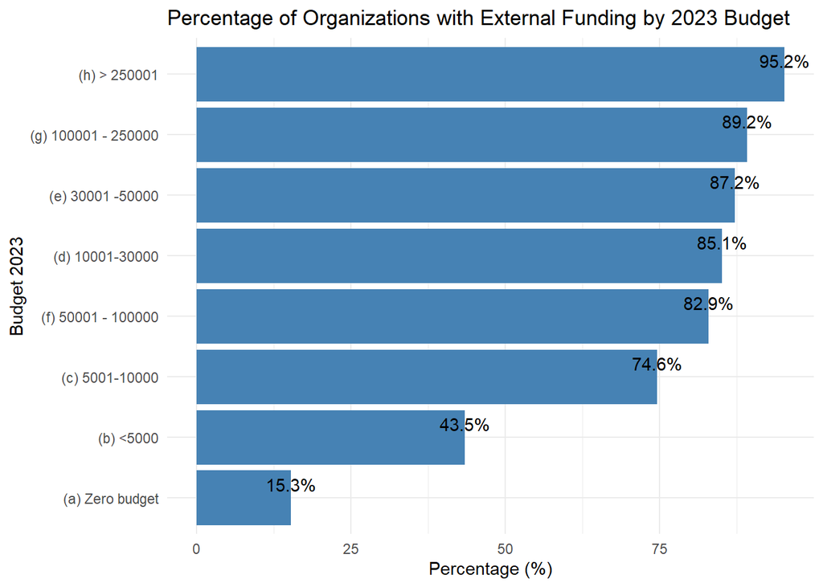

Among the organizations that received external funding between 2021 and 2023, 83.4% reported receiving funding in 2021, 92% in 2022, and 97.3% in 2023.

| Year | n | Percentage |
| --- | --- | --- |
| 2023 | 692 | 97.3 |
| 2022 | 654 | 92.0 |
| 2021 | 593 | 83.4 |

**Organizations that received external funding during 2023**

| Registration | count | Percentage |
| --- | --- | --- |
| No | 75 | 11.16 |
| Yes | 597 | 88.84 |

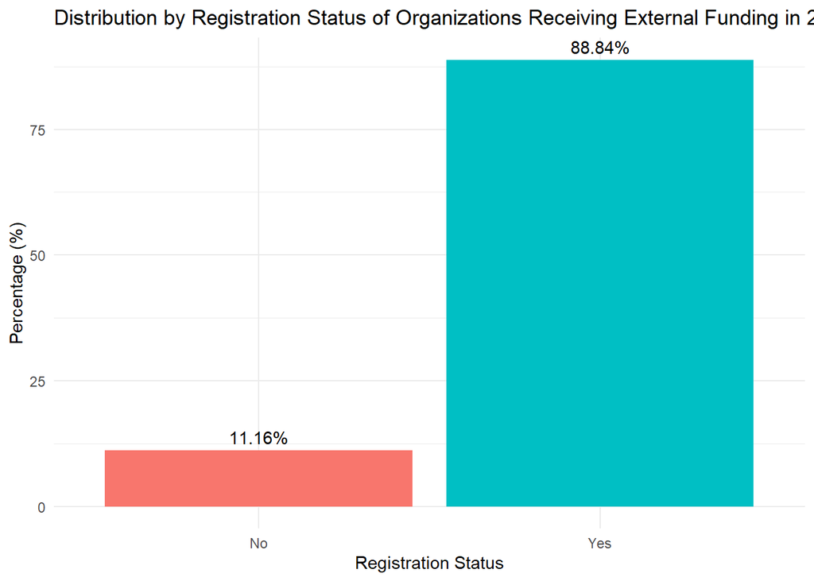

On the other hand, most organizations that received external funding in the past year were characterized by having a national scope: 49.6%.

| Scope | n | Percentage |
| --- | --- | --- |
| Diaspora | 9 | 1.30 |
| Global | 40 | 5.78 |
| Local | 204 | 29.48 |
| National | 343 | 49.57 |
| Regional | 82 | 11.85 |
| Transnational | 14 | 2.02 |

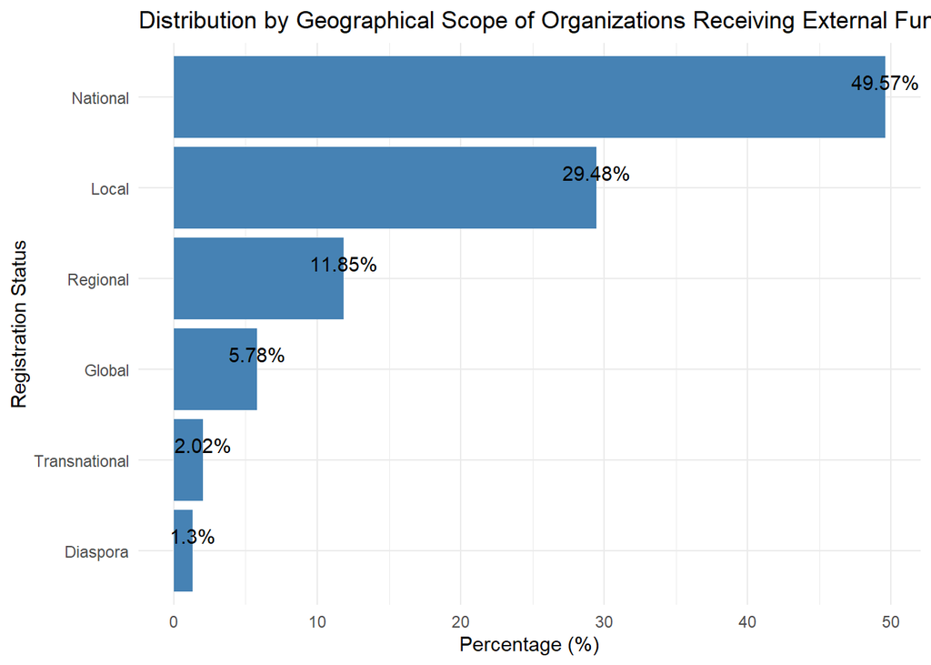

Formation period

n

Percentage

2. From 2015 to 2020

212

30.64

4. From 2000 to 2009

166

23.99

3. From 2010 to 2014

125

18.06

5. Before 2000

124

17.92

1. 2021-2023

65

9.39

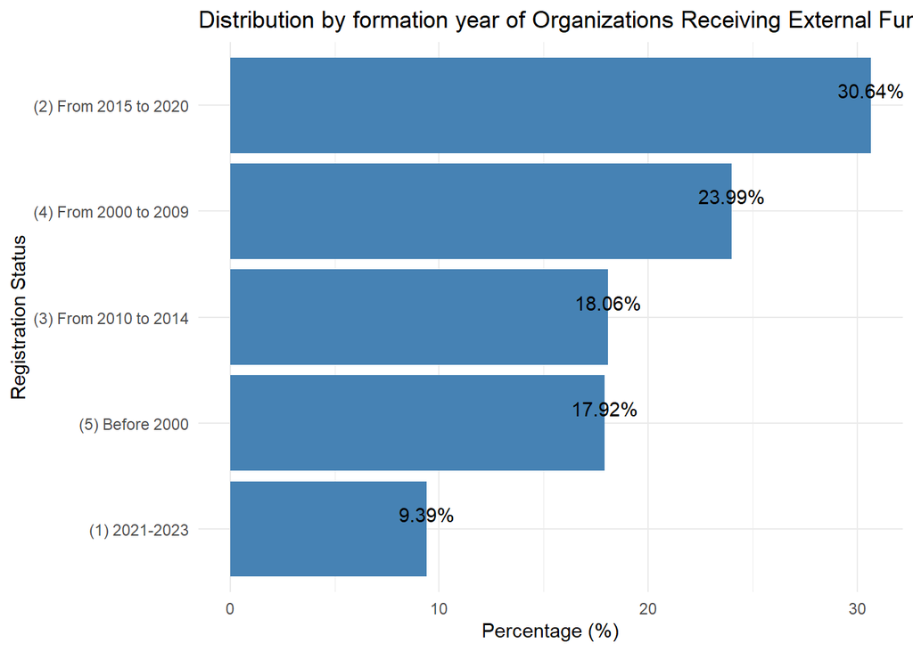

Budget 2023

n

Percentage

8. > 250001

138

19.94

4. 10001-30000

126

18.21

6. 50001 - 100000

101

14.60

7. 100001 - 250000

99

14.31

3. 5001-10000

84

12.14

5. 30001 -50000

75

10.84

2. <5000

60

8.67

1. Zero budget

9

1.30

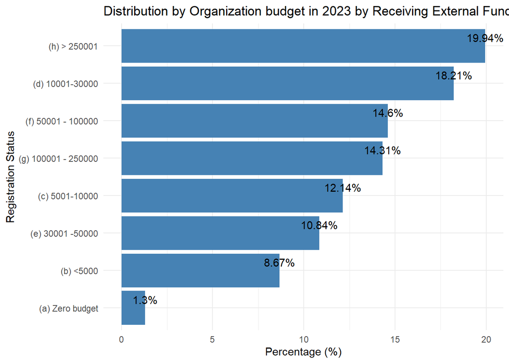

**Percentage of external funding received in total budget by year**

| Range | Percentage 2023 | Percentage 2022 | Percentage 2021 |
| --- | --- | --- | --- |
| 0 | 2.7 | 6.8 | 12.1 |
| 10 | 6.9 | 6.4 | 8.7 |
| 20 | 4.5 | 7.3 | 6.4 |
| 30 | 6.8 | 5.7 | 5.2 |
| 40 | 5.2 | 4.8 | 4.3 |
| 50 | 4.9 | 5.3 | 5.3 |
| 60 | 5.1 | 4.7 | 5.2 |
| 70 | 7.6 | 8.5 | 6.7 |
| 80 | 11.7 | 9.0 | 7.0 |
| 90 | 15.9 | 15.7 | 14.7 |
| 100 | 28.8 | 25.8 | 24.4 |

Examining the Percentage of external funding received each year in 2021, 2022, and 2023, we can see that in the last two years, the median distribution was around 80, whereas in 2021 it was approximately r 70. Additionally, the average has increased each year: it was 59.0814815 in 2021 and rose to 68.9873418 by 2023.

**Main Sources of External Funding**

Q15. Considering these definitions, what were your group, organization, and/or movement’s key sources of external funding between 2021 and 2023?

As it is showns below, the main source of external funding among organizations participating in the survey is from Women’s and Feminist Funds, followed by International Non-Governmental Organizations (INGOs).

| Source | Percentage |
| --- | --- |
| Multirateral | 16.7 |
| Bilateral | 20.0 |
| Philanthropic | 30.4 |
| Feminist | 55.7 |
| Private | 9.6 |
| INGOS | 36.0 |
| Individual | 22.5 |
| Government | 15.5 |
| Other | 6.2 |

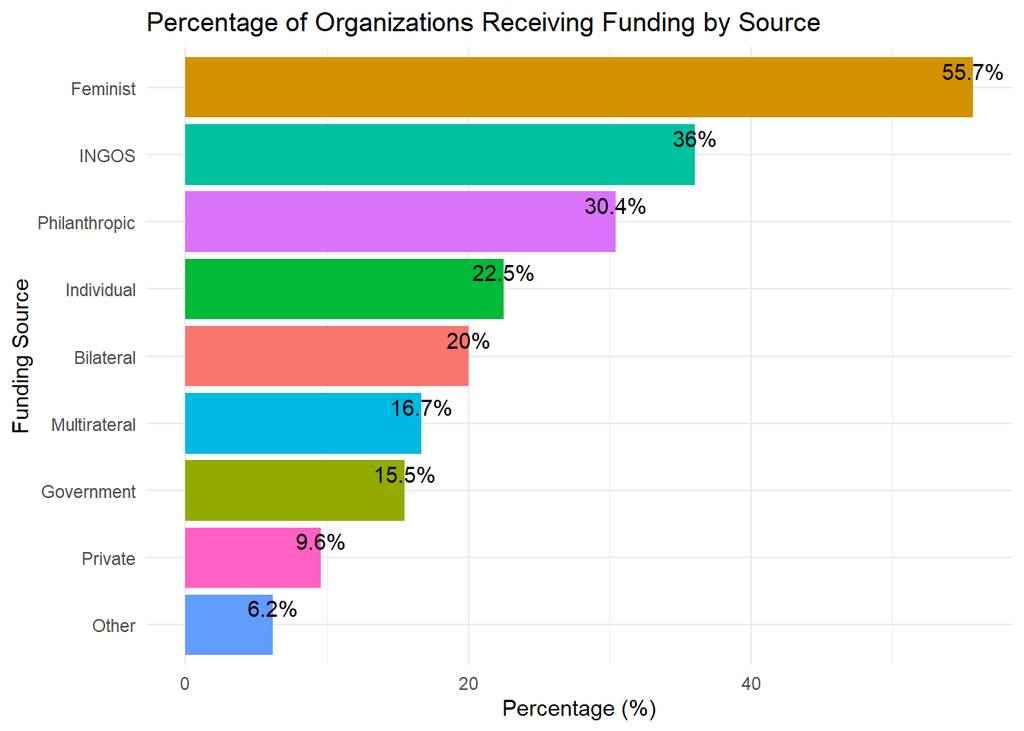

Regarding organizational registration, it is noted that registered organizations received more funding from multilateral, bilateral, private, and government sources compared to those that are not registered.

| Registered | Total | Multirateral | Bilateral | Philanthropic | Feminist | Private | INGOS | Individual | Government | Other |
| --- | --- | --- | --- | --- | --- | --- | --- | --- | --- | --- |
| No registered | 79 | 3.8 | 7.6 | 29.1 | 62.0 | 3.8 | 26.6 | 20.3 | 5.1 | 3.8 |
| Registered | 610 | 18.9 | 21.8 | 30.3 | 54.8 | 10.5 | 37.4 | 23.0 | 17.0 | 6.1 |

| Scope | Total | Multirateral | Bilateral | Philanthropic | Feminist | Private | INGOS | Individual | Government | Other |
| --- | --- | --- | --- | --- | --- | --- | --- | --- | --- | --- |
| Diaspora | 9 | 0.0 | 11.1 | 44.4 | 77.8 | 0.0 | 44.4 | 0.0 | 11.1 | 0.0 |
| Global | 42 | 26.2 | 33.3 | 47.6 | 26.2 | 21.4 | 16.7 | 50.0 | 21.4 | 14.3 |
| Local | 212 | 7.5 | 9.9 | 25.0 | 55.2 | 9.9 | 33.0 | 27.8 | 21.2 | 5.7 |
| National | 351 | 20.5 | 23.1 | 27.4 | 58.7 | 8.8 | 40.2 | 17.4 | 12.8 | 6.3 |
| Regional | 83 | 24.1 | 27.7 | 47.0 | 59.0 | 8.4 | 36.1 | 21.7 | 7.2 | 3.6 |
| Transnational | 14 | 0.0 | 14.3 | 28.6 | 42.9 | 0.0 | 28.6 | 7.1 | 28.6 | 7.1 |

Formation period

Total

Multirateral

Bilateral

Philanthropic

Feminist

Private

INGOS

Individual

Government

Other

1. 2021-2023

67

3.0

13.4

26.9

50.7

4.5

26.9

26.9

13.4

9.0

2. From 2015 to 2020

221

11.8

14.9

24.4

58.8

8.6

37.6

24.9

15.4

5.9

3. From 2010 to 2014

131

14.5

16.0

34.4

60.3

11.5

33.6

22.9

9.2

6.9

4. From 2000 to 2009

167

28.1

25.1

33.5

59.3

6.6

37.1

16.8

18.0

6.0

5. Before 2000

125

20.0

29.6

34.4

43.2

16.0

39.2

23.2

20.0

4.8

Budget 2023

Total

Multirateral

Bilateral

Philanthropic

Feminist

Private

INGOS

Individual

Government

Other

1. Zero budget

17

0.0

0.0

0.0

35.3

11.8

29.4

29.4

11.8

23.5

2. <5000

64

1.6

4.7

20.3

50.0

3.1

39.1

21.9

12.5

9.4

3. 5001-10000

85

9.4

7.1

17.6

56.5

0.0

35.3

18.8

15.3

5.9

4. 10001-30000

131

6.9

13.7

22.1

55.7

5.3

33.6

19.8

13.7

4.6

5. 30001 -50000

75

14.7

14.7

20.0

64.0

6.7

40.0

30.7

12.0

8.0

6. 50001 - 100000

102

17.6

22.5

31.4

58.8

6.9

35.3

18.6

19.6

4.9

7. 100001 - 250000

99

28.3

20.2

41.4

47.5

15.2

36.4

19.2

12.1

6.1

8. > 250001

138

31.9

44.2

51.4

59.4

21.7

36.2

27.5

20.3

4.3

[output not shown]

*Funding from 2023*

| Range | % Bilateral | % Feminist | % Goverment | % Individual | % INGOS | % Multirateral | % Philanthropic | % Private | % Other |
| --- | --- | --- | --- | --- | --- | --- | --- | --- | --- |
| 0 | 18.3 | 12.9 | 14.5 | 15.6 | 20.3 | 15.1 | 12.5 | 19.1 | 34.1 |
| 10 | 12.0 | 16.2 | 29.1 | 39.4 | 15.2 | 16.8 | 14.4 | 29.4 | 20.5 |
| 20 | 11.3 | 11.1 | 17.3 | 19.4 | 14.8 | 16.0 | 15.3 | 23.5 | 15.9 |
| 30 | 13.4 | 12.4 | 6.4 | 9.4 | 10.5 | 15.1 | 11.1 | 13.2 | 9.1 |
| 40 | 7.0 | 7.3 | 7.3 | 4.4 | 9.8 | 9.2 | 12.0 | 7.4 | NA |
| 50 | 3.5 | 7.1 | 4.5 | 3.8 | 7.8 | 2.5 | 8.3 | 2.9 | 2.3 |
| 60 | 12.0 | 5.3 | 2.7 | 1.2 | 5.5 | 9.2 | 5.6 | NA | 2.3 |
| 70 | 7.0 | 5.3 | 3.6 | 1.9 | 3.1 | 5.0 | 6.0 | NA | NA |
| 80 | 5.6 | 6.3 | 5.5 | 1.2 | 5.1 | 5.9 | 6.0 | 4.4 | 6.8 |
| 90 | 6.3 | 7.1 | 3.6 | 2.5 | 4.3 | 1.7 | 2.8 | NA | 6.8 |
| 100 | 3.5 | 9.1 | 5.5 | 1.2 | 3.5 | 3.4 | 6.0 | NA | 2.3 |

*Funding from 2022*

| Range | % Bilateral | % Feminist | % Goverment | % Individual | % INGOS | % Multirateral | % Philanthropic | % Private | % Other |
| --- | --- | --- | --- | --- | --- | --- | --- | --- | --- |
| 0 | 21.1 | 22.5 | 21.8 | 26.2 | 24.2 | 22.7 | 21.3 | 23.5 | 40.9 |
| 10 | 11.3 | 14.9 | 22.7 | 36.9 | 11.7 | 17.6 | 13.0 | 39.7 | 18.2 |
| 20 | 14.1 | 12.4 | 15.5 | 14.4 | 17.2 | 16.0 | 11.1 | 10.3 | 11.4 |
| 30 | 11.3 | 8.8 | 7.3 | 5.0 | 12.1 | 12.6 | 12.5 | 10.3 | 4.5 |
| 40 | 3.5 | 5.3 | 4.5 | 3.8 | 5.5 | 7.6 | 9.3 | 5.9 | 2.3 |
| 50 | 5.6 | 8.8 | 4.5 | 1.9 | 9.0 | 8.4 | 7.4 | NA | 2.3 |
| 60 | 5.6 | 4.5 | 1.8 | 1.9 | 4.3 | 3.4 | 2.8 | 2.9 | NA |
| 70 | 7.0 | 4.3 | 7.3 | 1.9 | 3.1 | 3.4 | 9.3 | 1.5 | NA |
| 80 | 8.5 | 3.3 | 3.6 | 2.5 | 6.2 | 3.4 | 5.1 | 4.4 | 9.1 |
| 90 | 5.6 | 6.1 | 3.6 | 1.9 | 2.7 | 3.4 | 3.2 | 1.5 | 2.3 |
| 100 | 4.9 | 7.8 | 5.5 | 1.9 | 3.9 | 1.7 | 4.2 | NA | 6.8 |
| NA | 1.4 | 1.3 | 1.8 | 1.9 | NA | NA | 0.9 | NA | 2.3 |

*Funding from 2021*

| Range | % Bilateral | % Feminist | % Goverment | % Individual | % INGOS | % Multirateral | % Philanthropic | % Private | % Other |
| --- | --- | --- | --- | --- | --- | --- | --- | --- | --- |
| 0 | 34.5 | 30.1 | 31.8 | 26.9 | 28.9 | 27.7 | 24.1 | 23.5 | 43.2 |
| 10 | 7.0 | 10.4 | 25.5 | 33.1 | 13.7 | 16.0 | 12.5 | 38.2 | 6.8 |
| 20 | 11.3 | 10.9 | 11.8 | 13.8 | 12.5 | 12.6 | 13.0 | 14.7 | 13.6 |
| 30 | 5.6 | 8.8 | 6.4 | 3.8 | 8.6 | 9.2 | 6.0 | 10.3 | 4.5 |
| 40 | 6.3 | 5.8 | 1.8 | 1.9 | 6.2 | 6.7 | 9.3 | 5.9 | 2.3 |
| 50 | 4.9 | 5.8 | 2.7 | 1.9 | 6.6 | 7.6 | 7.9 | NA | 2.3 |
| 60 | 4.2 | 3.0 | 1.8 | 3.1 | 3.1 | 3.4 | 4.2 | 1.5 | NA |
| 70 | 9.2 | 2.5 | 4.5 | 1.9 | 3.9 | 4.2 | 4.2 | NA | 2.3 |
| 80 | 5.6 | 5.1 | 2.7 | 3.1 | 3.1 | 5.0 | 6.9 | 1.5 | 4.5 |
| 90 | 4.2 | 7.3 | 2.7 | 1.9 | 3.5 | 4.2 | 2.8 | 1.5 | 2.3 |
| 100 | 4.2 | 6.3 | 3.6 | 3.1 | 5.9 | 1.7 | 6.0 | 1.5 | 9.1 |
| NA | 2.8 | 4.0 | 4.5 | 5.6 | 3.9 | 1.7 | 3.2 | 1.5 | 9.1 |

**Organizations that received funding from new donors between 2021 and 2023**

Q18. Between 2021 and 2023, which new funders, if any, did you receive funding from?

It is noted that 60.6% of organizations reported receiving funding from new donors between 2021 and 2023. Among these organizations, feminist funds are the primary source of new funding

**Reception of new funding between 2021 and 2023**

| Source | Percentage |
| --- | --- |
| No new founder | 7.5 |
| New founder | 60.6 |

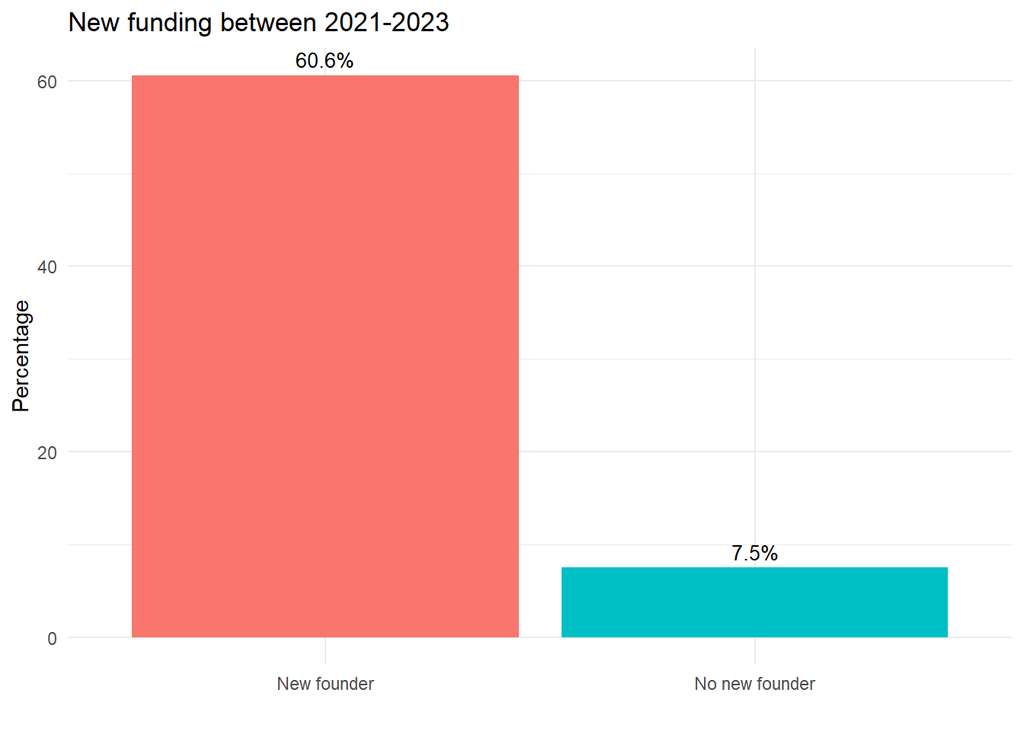

*Source of new funding*

| Source | Percentage |
| --- | --- |
| Multilateral | 13.8 |
| Bilateral | 13.6 |
| Philanthropic | 24.6 |
| Feminist | 48.1 |
| Private | 9.0 |
| INGOS | 31.1 |
| Individual | 17.3 |
| Government | 11.8 |
| Other | 4.7 |

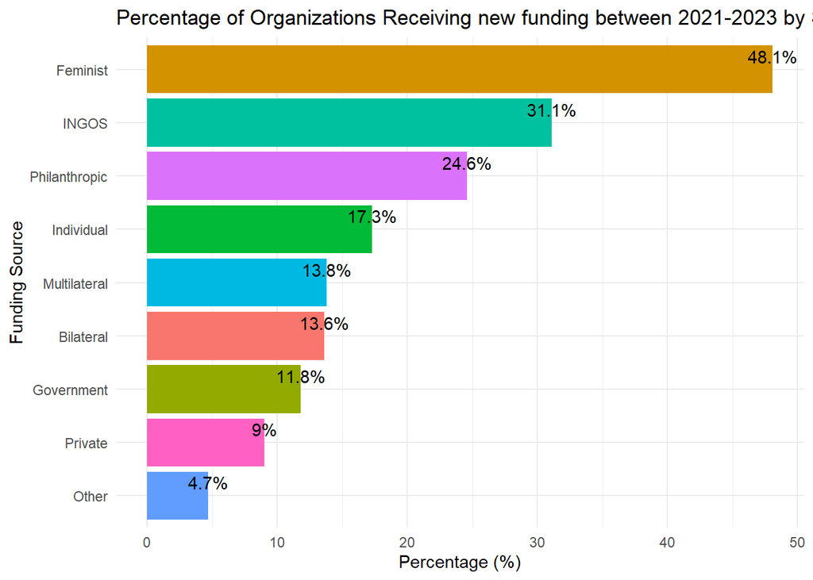

| Scope | Total | Multilateral | Bilateral | Philanthropic | Feminist | Private | INGOS | Individual | Government | Other |
| --- | --- | --- | --- | --- | --- | --- | --- | --- | --- | --- |
| Global | 31 | 22.6 | 25.8 | 45.2 | 22.6 | 22.6 | 22.6 | 35.5 | 19.4 | 3.2 |
| Local | 183 | 8.2 | 6.6 | 22.4 | 48.1 | 10.4 | 25.1 | 21.9 | 17.5 | 5.5 |
| National | 304 | 14.8 | 15.1 | 20.1 | 49.3 | 7.6 | 35.2 | 13.2 | 9.2 | 4.3 |
| Regional | 68 | 23.5 | 19.1 | 42.6 | 51.5 | 5.9 | 29.4 | 17.6 | 1.5 | 5.9 |

Formation period

Total

Multilateral

Bilateral

Philanthropic

Feminist

Private

INGOS

Individual

Government

Other

1. 2021-2023

51

5.9

13.7

23.5

54.9

3.9

25.5

23.5

7.8

7.8

2. From 2015 to 2020

189

10.6

8.5

19.6

51.3

6.9

30.2

18.0

11.6

3.2

3. From 2010 to 2014

101

10.9

15.8

30.7

47.5

10.9

30.7

13.9

13.9

6.9

4. From 2000 to 2009

147

21.1

16.3

22.4

49.0

7.5

32.0

15.0

8.2

6.1

5. Before 2000

113

15.9

16.8

31.0

38.9

15.0

34.5

19.5

16.8

1.8

Budget 2023

Total

Multilateral

Bilateral

Philanthropic

Feminist

Private

INGOS

Individual

Government

Other

1. Zero budget

15

0.0

0.0

0.0

53.3

6.7

20.0

13.3

6.7

20.0

2. <5000

48

4.2

6.2

14.6

47.9

4.2

31.2

18.8

14.6

8.3

3. 5001-10000

66

9.1

4.5

18.2

45.5

4.5

25.8

21.2

13.6

3.0

4. 10001-30000

106

6.6

13.2

17.0

54.7

6.6

29.2

15.1

10.4

1.9

5. 30001 -50000

68

16.2

10.3

16.2

54.4

5.9

36.8

13.2

11.8

7.4

6. 50001 - 100000

89

15.7

10.1

28.1

47.2

6.7

32.6

14.6

16.9

6.7

7. 100001 - 250000

87

26.4

13.8

28.7

40.2

11.5

34.5

16.1

8.0

4.6

8. > 250001

122

16.4

27.9

41.0

45.9

17.2

30.3

22.1

10.7

1.6

**Loss of funding**

Q19. Between 2021 and 2023, did your group, organization and/or movement lose funding from any long-term funders who previously supported your work?

| Source | Percentage |
| --- | --- |
| No funding lost | 53.6 |
| Yes, lost funding | 46.4 |

[figure not shown]

**Organizations that Experienced a Decrease in Funding by Source Between 2021 and 2023**

| Source | Percentage |
| --- | --- |
| Multilateral | 8.2 |
| Bilateral | 6.6 |
| Philanthropic | 11.8 |
| Feminist | 3.4 |
| Private | 11.3 |
| INGOS | 15.2 |
| Individual | 8.0 |
| Government | 5.7 |
| Other | 2.6 |

[figure not shown]

| Scope | Total | No funding lost | Yes, lost funding |
| --- | --- | --- | --- |
| Global | 42 | 45.2 | 54.8 |
| Local | 212 | 54.2 | 45.8 |
| National | 351 | 53.6 | 46.4 |
| Regional | 83 | 55.4 | 44.6 |

Formation period

Total

No funding lost

Yes, lost funding

1. 2021-2023

67

71.6

28.4

2. From 2015 to 2020

221

57.0

43.0

3. From 2010 to 2014

131

52.7

47.3

4. From 2000 to 2009

167

47.9

52.1

5. Before 2000

125

46.4

53.6

Budget 2023

Total

Multilateral

Bilateral

Philanthropic

Feminist

Private

INGOS

Individual

Government

Other

1. Zero budget

8

0.0

0.0

0.0

12.5

25.0

25.0

12.5

12.5

12.5

2. <5000

27

7.4

0.0

11.1

3.7

33.3

22.2

25.9

11.1

11.1

3. 5001-10000

36

8.3

2.8

16.7

5.6

19.4

44.4

13.9

19.4

5.6

4. 10001-30000

51

11.8

5.9

17.6

3.9

27.5

27.5

19.6

13.7

5.9

5. 30001 -50000

39

10.3

12.8

7.7

7.7

28.2

35.9

10.3

2.6

7.7

6. 50001 - 100000

45

17.8

8.9

15.6

2.2

24.4

22.2

15.6

4.4

6.7

7. 100001 - 250000

52

26.9

17.3

30.8

7.7

11.5

26.9

11.5

11.5

0.0

8. > 250001

72

18.1

25.0

38.9

9.7

12.5

23.6

12.5

11.1

1.4

**Loss of funding impact**

Q20. What impact has this loss of funding had on your group, organization and/or movement?

| Source | Percentage |
| --- | --- |
| No big impact | 11.9 |
| Staff reduction | 32.3 |
| Activity reduction | 60.2 |
| Discontinuation of programs or projects | 11.9 |
| Staff faced a salary gap | 34.2 |
| Other | 12.2 |

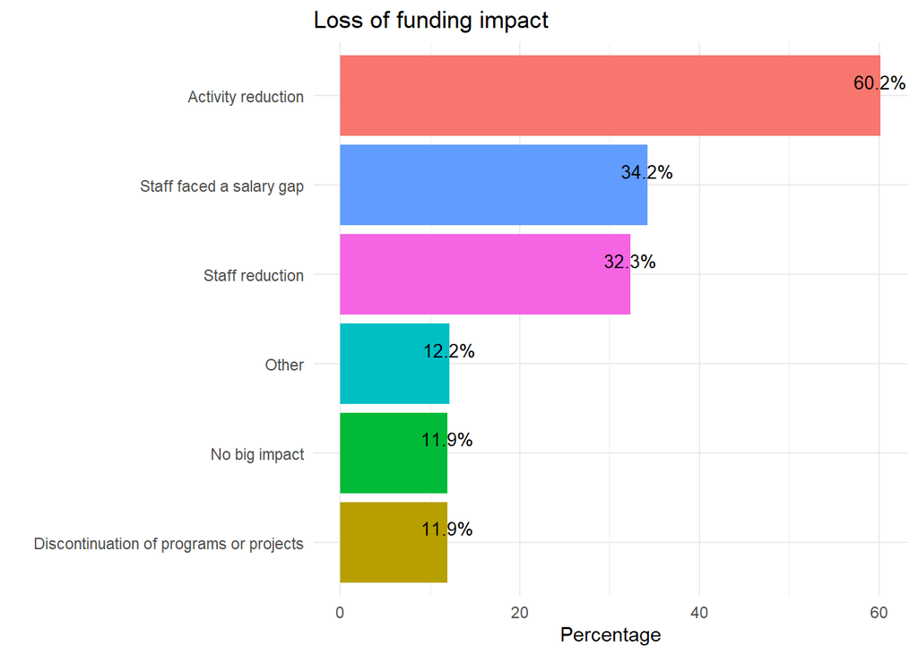

| Scope | Total | No big impact | Staff reduction | Activity reduction | Discontinuation of programs or projects | Staff faced a salary gap | Other |
| --- | --- | --- | --- | --- | --- | --- | --- |
| Global | 22 | 31.8 | 13.6 | 40.9 | 31.8 | 27.3 | 18.2 |
| Local | 96 | 12.5 | 34.4 | 62.5 | 12.5 | 33.3 | 7.3 |
| National | 155 | 11.0 | 35.5 | 59.4 | 11.0 | 36.1 | 12.9 |
| Regional | 36 | 5.6 | 27.8 | 72.2 | 5.6 | 27.8 | 19.4 |

Formation period

Total

No big impact

Staff reduction

Activity reduction

Discontinuation of programs or projects

Staff faced a salary gap

Other

1. 2021-2023

18

0.0

22.2

66.7

0.0

44.4

38.9

2. From 2015 to 2020

89

11.2

28.1

60.7

11.2

33.7

10.1

3. From 2010 to 2014

60

11.7

31.7

68.3

11.7

43.3

5.0

4. From 2000 to 2009

85

12.9

36.5

56.5

12.9

34.1

14.1

5. Before 2000

67

14.9

35.8

55.2

14.9

23.9

11.9

Budget 2023

Total

No big impact

Staff reduction

Activity reduction

Discontinuation of programs or projects

Staff faced a salary gap

Other

1. Zero budget

7

0.0

28.6

57.1

0.0

0.0

14.3

2. <5000

27

7.4

18.5

55.6

7.4

25.9

3.7

3. 5001-10000

32

0.0

37.5

75.0

0.0

46.9

12.5

4. 10001-30000

50

6.0

34.0

68.0

6.0

42.0

12.0

5. 30001 -50000

36

8.3

38.9

52.8

8.3

44.4

13.9

6. 50001 - 100000

43

14.0

30.2

55.8

14.0

34.9

14.0

7. 100001 - 250000

52

11.5

36.5

69.2

11.5

36.5

11.5

8. > 250001

72

25.0

29.2

50.0

25.0

22.2

13.9